# Ncore music genre analysis

Earlier this year I saw an excellent google [visualization](http://research.google.com/bigpicture/music/) showing which music genres are still popular from a given date. That graph shows that the poularity of modern rock is shrinking. In a way this is not surprising, as today there are so many different genres for a very diverse audience, so unlike many blogs and sites commenting on that graph, I am not pessimistic about the future of rock. Time will tell which of today's music deserves to have future…

**The analysis can be divided into the following steps:**

1. **Parse genre data:** during the torrent data sheet processing, the genre information is stored in one field of a csv file, where each genre is separated by an underscore. In this step, the torrent data file is read by a Perl script, that separates the genre fields (as more genres can be associated to one music torrent), and saves it paired with the torrent ID in a new csv file.
2. **Clean genre list:** the originally assigned genres form a very heterogenous list with arbitrary definitions and typos. In this step, I define a smaller genre set that covers as many music files as possible.
3. **Summarizing genre data:** the number of torrent files and downloads are summarized over the associated genres. In the resulted dataframe each row represents one genre.
4. **Visualization and discussion:** I was interested in how the number of torrents and downloads distributed among genres and genre categories. For the visualization I chose *treemap* that is especially good to get a qualitative idea about the distribution of hierachical categories, and *barchart* that allows a more quantitative insight with a much better resolution. With these methods we can point out genres that are more frequently uploaded and those that are more frequently downloaded.

### Step 1. Reading and separating genre information:

Upon downloading the torrent datasheet, every piece of information is saved into a csv file, where each line corresponds to one torrent ID. As potentially multiple genres can be associated to one torrent ID, genres are fused together with underscores to keep all genres in a single field of the csv sheet.

In the first step, the genre field of the csv file had to be separated into individual genres. As this process was really slow with R, I decided to use Perl. The suitable script saved each genre with the corresponding torrent ID into a new csv file, that could be read by R directly as a dataframe. The following example shows how this script worked:

**input:**

> 1488270,5,1,2014-02-10,21:53:02,12,MP3,EN,house_dance_electronic

**output:**

> 1488270,house

```r
# call Perl script, save csv
system("perl Genre_reader.pl torrent_data_NoTitle.csv")

# Reading csv file:
raw_genres <- read.csv("genres_raw.csv", header = T)
```

An exploratory analysis gives an idea how heterogenous is the genre definition set.

```r
AssignedGenres <- nrow(raw_genres)
raw_genre_difinitions <- length(table(raw_genres$Genre))
TorrentNumber <- length(table(raw_genres$TorrentID))
UnAssignedTorrents <- nrow(raw_genres[raw_genres$Genre == "Na", ])
UnAssignedRatio <- round(100 * UnAssignedTorrents/length(table(raw_genres$TorrentID)),
    2)

cat("Number of torrent files:", TorrentNumber, "\nNumber of assigned genres:",
    AssignedGenres, "\nNumber of different genre definitions:", raw_genre_difinitions,
    "\nNumber of torrents without genre definition:", UnAssignedTorrents, "(",
    UnAssignedRatio, "% of the total torrent population)\n")
```

```
## Number of torrent files: 70282
## Number of assigned genres: 142248
## Number of different genre definitions: 2279
## Number of torrents without genre definition: 2684 ( 3.82 % of the total torrent population)
```

### Step 2. Cleaning genre list

To make the genre definition list more concise, with the combination of Perl scripts and R commands, I constructed a genre mask set to fix the most frequently made typo-s and inconsistent defintions. In this process I selected the first 100 most commonly used genres and manually processed them to get rid of non-meaningful words and typos. I also pooled closely related genres like “nordic metal” and “viking metal”. Then I repeated this process where newer and newer definitions come up to the top 100.

#### Step 2/a: the most frequently used 100 genres

To characterize the homogeneity and representativeness of the initial definition set, I calculated the ratio of torrents represented by the most frequently used 100 genres:

```r
genre_table <- table(raw_genres$Genre)
genre_table <- sort(genre_table, decreasing = T)
top100_genre <- labels(genre_table[1:100])[[1]]
Top100_genre_count <- sum(genre_table[1:100])
All_genre_count <- sum(genre_table)
Top100_genre_ratio <- round(Top100_genre_count/All_genre_count * 100, digits = 1)

write(top100_genre, "top100genres.txt", sep = " ")
returned <- system2("./Top100_representativeness.pl", stdout = TRUE)

cat("Most frequently used 100 genre definitions:\n", top100_genre)
```

```
## Most frequently used 100 genre definitions:
##  rock house pop metal electronic trance dance hop techno progressive hip jazz psychedelic and alternative folk classical blues ost bass ambient drum psytrance punk hardcore tech disco hard 90s House deep dts 24bit new music world downtempo live age Metal 80s death soul dubstep funk Dance rap heav…
```

```r
cat("TOP100 genre definitions covers", Top100_genre_ratio, "percent of all genre annotations.")
```

```
## TOP100 genre definitions covers 86 percent of all genre annotations.
```

```r
writeLines(returned)
```

```
##
## Total number of torrents: 70283
## Number of torrents represented by the TOP100 genre list: 63947. (90%)
```

The 100 most commonly used genres cover 90% of the total torrent population, and 86% of the total genre definition.

Usage frequency of the top 100 genres:

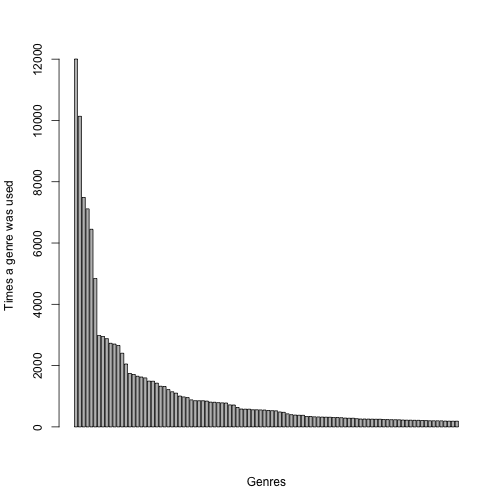

```r
barplot(genre_table[1:100], names.arg = "", xlab = "Genres", ylab = "Times a genre was used")
```

The graph shows that there are only a few very frequently used genres, and most genres in the Top100 are already quite rare. So the Top 100 definition quite well covers the dataset, though 100 definition is still too many to visualize and it also has incosistentencies. In the following section I show the result of the optimization.

#### Step 2/b: optimized dataset:

I have developed a genre mask the fixed most commonly occuring typos, omitted non-real genre definitions (“192kb”, “80s”, “live” etc.). At the end of the optimization, I have developed a genre mask with 203 entries that restricted the genre set to only 42 definitions (see: mask_definitions.txt and Tag_cleaner.pl) that were grouped into five categories: “rock”, “electronic”, “pop”, “hip-hop”, “other”.

**The list of the final genre definitions:**

- **Electronic:** “dubstep” “chillout/ambient” “drum'n'bass” “electronic” “psychedelic/acid/goa” “house” “trance/techno”
- **Hip-hop:** “rnb” “funk” “rap” “hip-hop”
- **Other:** “musical” “swing” “meditation” “mulatos” “latin” “comedy” “soul” “reggae” “country” “ost” “audiobook” “blues” “jazz” “classical” “folk”
- **Pop:** “italo-disco” “indie” “synthpop” “dicso” “europop” “dance” “pop”
- **rock:** “nemzeti-rock” “rock'n'roll” “psychedelic-rock” “alternative” “punk” “dark-metal” “hardcore” “dark-rock” “rock”

```r
# running the final Perl script that genereates a cleaned torrent ID list
# with the cleaned genre
report <- system2("./Tag_cleaner.pl", args = c("torrent_data_NoTitle.csv"),
    stdout = TRUE)
writeLines(report)
```

```
## Non-covered genres: 7939 (5%)
## Covered, but non-valid genres: 13659 (9%)
## Valid genres: 123745 (85%)
## Torrents with at least one valid genre mask: 67852 (92%)
```

```r
CleanGenre <- read.csv("genres_clean_final.csv", header = T)
```

According to the report, most of the genre definitions are masked (95%) and most of the masked genres (85%) were associated to any of the valid genre definitions. The valid genre definitions efficiently cover the torrent population, where 92% of torrent files has at least one associated genre definition.

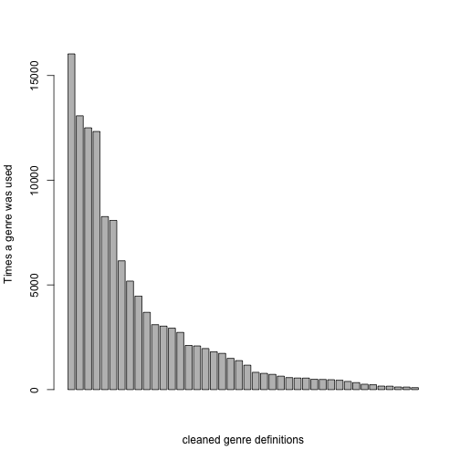

```r
genre_table <- sort(table(CleanGenre$genre), decreasing = T)
barplot(genre_table, names.arg = "", xlab = "cleaned genre definitions", ylab = "Times a genre was used")
```

### Step 3. Summarizing genre data:

Summaraizing the number of torrents belonging different genres and the corresponding download number is also not trivial, as torrents often have contradicting genre annotations (In extreme cases, a single torrent can have 15 assigned genres). So I have decided to split both the torrent count and download number between genres. **For example:** if there is a torrent with 120 downloads and three assigned genres, then each genre got 1/3 count and 40 downloads.

```r
# Creating a restricted dataset to make the process quick, will be removed
# in the final verision.  CleanGenre_small <- CleanGenre[1:5000, ]

# Adding an extra column to the cleaned genre dataframe that contain how
# many genres were assigned to a given torrent ID:
CleanGenre <- read.csv("genres_clean_final.csv", header = T)
ID_Table <- table(CleanGenre$ID)
system.time(Count <- sapply(as.character(CleanGenre$ID), function(x) ID_Table[x]))
```

```
##    user  system elapsed
## 582.915   1.735 585.580
```

```r
# To fill dataframe with torrent data -> at first the torrent datafile is
# loaded:
Torrent_df <- read.csv(file = "torrent_data_NoTitle.csv", header = T)
Torrent_df <- Torrent_df[!is.na(Torrent_df$TorrentID), ]
Torrent_df$Downloaded <- as.numeric(as.character(Torrent_df$Downloaded))  # set download number numeric

### Fill dataframe with download number:
DownloadCount <- sapply(CleanGenre$ID, function(x) Torrent_df[Torrent_df$TorrentID ==
    x, "Downloaded"][1])

# Extend genre dataframe with the previously calculated data (already
# normalized to the number of assigned genres):
CleanGenre$TorrentCount <- 1/Count
CleanGenre$Downloads <- CleanGenre$TorrentCount * DownloadCount

# Genre definitions in the cleaned dataset:
genres <- names(table(CleanGenre$genre))
categories <- sapply(genres, function(x) CleanGenre[CleanGenre$genre == x, "Category"][1])

# Combining all data into a single dataframe:
GenreDf <- data.frame(genres = genres, categories = categories)

# calculate how many torrents belong to each genre definition:
TorrentCount <- sapply(GenreDf$genres, function(x) sum(CleanGenre[CleanGenre$genre ==
    x, "TorrentCount"]))
GenreDf$Count <- TorrentCount

# calculte how many downloads belong to each genre definition:
TorrentDownloads <- sapply(GenreDf$genres, function(x) sum(CleanGenre[CleanGenre$genre ==
    x, "Downloads"]))
GenreDf$Downloads <- TorrentDownloads

# Calculating the 'relative popularity' of torrents: average download number
GenreDf$averageDownloads <- GenreDf$Downloads/GenreDf$Count

# Sorting dataframe based on category then based on torrent count:
GenreDf <- GenreDf[order(GenreDf[, "categories"], GenreDf[, "Count"]), ]  # Sorting for count
```

### Step 4. Visualization and discussion:

Before visualizing the summary, we assign colors to each genre that makes it easier to identify them on various graphs. There are base colors that are selected for categories then color gradient is generated from the base color to white based on the count of the given genre. (In the coloring function I have implemented a scaled coloring method where the intensity of the assigned color depends on the relative count value. In this case this method is not applicable as generally there is one or two large value with strong color, and a lot of small values with very faint colors.)

```r
# At first we assign colors to each genre to get a nice color gradient (R
# snipplet was developed for this task)
source("coloring.R")
GenreDf$colors <- coloring(GenreDf, level_1 = "categories", level_2 = "genres",
    values = "Count", scale = F)
```

To visualize the realtive distribution of different music categories and genres within categories, I created a treemap:

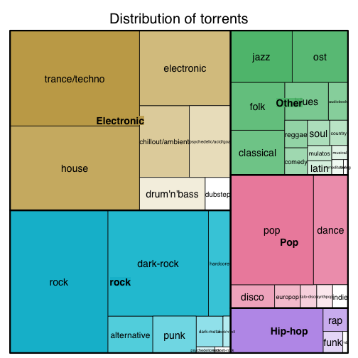

```r
# the treemap visualization requires "treemap" package to be installed:
if("treemap" %in% rownames(installed.packages()) == FALSE) {install.packages("treemap")}

library("treemap")

treemap(
    GenreDf,            # dataframe with the data to plot
    index  = c("categories","genres"),  # The nested categories
    vSize  = "Count",   # The values that determine the size of the rectangles
    type   = "color",   # Coloring method: use pre-defined colors
    vColor = "colors",  # Column name with color definitions
    title  = "Distribution of torrents",
    fontsize.title     = 20,
    fontsize.labels    = 14,
    force.print.labels = TRUE,
    drop.unused.levels = T,
    fontcolor.labels   = "black"
)
```

The visualization of the absolute download number gives an idea about the popularity of genres.

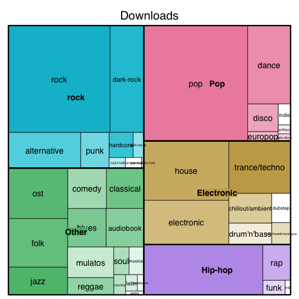

```r
#  :
treemap(
    GenreDf,            # dataframe with the data to plot
    index  = c("categories","genres"),  # The nested categories
    vSize  = "Downloads",   # The values that determine the size of the rectangles
    type   = "color",   # Coloring method: use pre-defined colors
    vColor = "colors",  # Column name with color definitions
    title  = "Downloads",
    fontsize.title     = 20,
    fontsize.labels    = 14,
    force.print.labels = TRUE,
    drop.unused.levels = T,
    fontcolor.labels   = "black"
)
```

This visulaization already indicates that the highest number of torrents not necessarely yields the highest number of downloads. There are genres that has more downloads although has lower number of torrents. To further amplify these differences, the average download number of a given genre was plotted (though this is not really fits to the scheme of the treemap visualization).

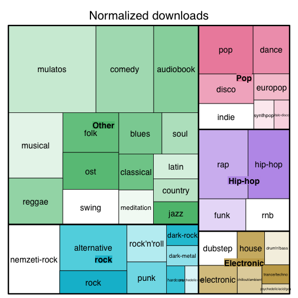

```r
#  :
treemap(
    GenreDf,            # dataframe with the data to plot
    index  = c("categories","genres"),  # The nested categories
    vSize  = "averageDownloads",   # The values that determine the size of the rectangles
    type   = "color",   # Coloring method: use pre-defined colors
    vColor = "colors",  # Column name with color definitions
    title  = "Normalized downloads",
    fontsize.title     = 20,
    fontsize.labels    = 14,
    force.print.labels = TRUE,
    drop.unused.levels = T,
    fontcolor.labels   = "black"
)
```

Some really interesting trends are visible on the last graph: there are some genres (usually representeb by a rather low number torrents) that have a high average download number.

To get a really comparative view of the genre usage, I created a barchart:

```
## NA
```

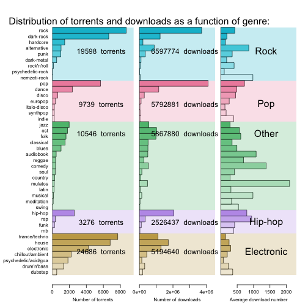

```r
source("triple_barchart.R")
triple_barplot(GenreDf)
```